# Module 7 Distribution Analysis

Patricia McGee

2/27/2022

## Assignment Instructions

Create your own visual analytics based on Distribution analysis. The visual will follow our textbook recommendation to use grid to enhance the comparisons between scatter plots or your variables. Attached is data set Download data setI used in my presentation. This data set is taken from R mtcars. You can retrieve this data set from R by typing> mtcars Post the result on your blog and express your opinion about Few’s recommendation.  
How to import the data to RStudio? Follow this guideline: https://support.rstudio.com/hc/en-us/articles/218611977-Importing-Data-with-RStudio (Links to an external site.) Another great resource from Distribution is the blog by Nathan Yau - the author of our textbook Visualize This. This blog posting title: How to Visualize and Compare Distributions in R. https://flowingdata.com/2012/05/15/how-to-visualize-and-compare-distributions/

## My Code

For this assignment, I have chosen to look at the mtcars dataset. I will be looking at the distribution of cylinders using a histogram and the distribution of horsepower by cylinder using histogram from the lattice package.

```r
carsData <- mtcars
summary(mtcars)
```

```
##       mpg             cyl             disp             hp
##  Min.   :10.40   Min.   :4.000   Min.   : 71.1   Min.   : 52.0
##  1st Qu.:15.43   1st Qu.:4.000   1st Qu.:120.8   1st Qu.: 96.5
##  Median :19.20   Median :6.000   Median :196.3   Median :123.0
##  Mean   :20.09   Mean   :6.188   Mean   :230.7   Mean   :146.7
##  3rd Qu.:22.80   3rd Qu.:8.000   3rd Qu.:326.0   3rd Qu.:180.0
##  Max.   :33.90   Max.   :8.000   Max.   :472.0   Max.   :335.0
##       drat             wt             qsec             vs
##  Min.   :2.760   Min.   :1.513   Min.   :14.50   Min.   :0.0000
##  1st Qu.:3.080   1st Qu.:2.581   1st Qu.:16.89   1st Qu.:0.0000
##  Median :3.695   Median :3.325   Median :17.71   Median :0.0000
##  Mean   :3.597   Mean   :3.217   Mean   :17.85   Mean   :0.4375
##  3rd Qu.:3.920   3rd Qu.:3.610   3rd Qu.:18.90   3rd Qu.:1.0000
##  Max.   :4.930   Max.   :5.424   Max.   :22.90   Max.   :1.0000
##        am              gear            carb
##  Min.   :0.0000   Min.   :3.000   Min.   :1.000
##  1st Qu.:0.0000   1st Qu.:3.000   1st Qu.:2.000
##  Median :0.0000   Median :4.000   Median :2.000
##  Mean   :0.4062   Mean   :3.688   Mean   :2.812
##  3rd Qu.:1.0000   3rd Qu.:4.000   3rd Qu.:4.000
##  Max.   :1.0000   Max.   :5.000   Max.   :8.000
```

```r
str(carsData)
```

```
## 'data.frame':    32 obs. of  11 variables:
##  $ mpg : num  21 21 22.8 21.4 18.7 18.1 14.3 24.4 22.8 19.2 ...
##  $ cyl : num  6 6 4 6 8 6 8 4 4 6 ...
##  $ disp: num  160 160 108 258 360 ...
##  $ hp  : num  110 110 93 110 175 105 245 62 95 123 ...
##  $ drat: num  3.9 3.9 3.85 3.08 3.15 2.76 3.21 3.69 3.92 3.92 ...
##  $ wt  : num  2.62 2.88 2.32 3.21 3.44 ...
##  $ qsec: num  16.5 17 18.6 19.4 17 ...
##  $ vs  : num  0 0 1 1 0 1 0 1 1 1 ...
##  $ am  : num  1 1 1 0 0 0 0 0 0 0 ...
##  $ gear: num  4 4 4 3 3 3 3 4 4 4 ...
##  $ carb: num  4 4 1 1 2 1 4 2 2 4 ...
```

## Plots

Code for the plots

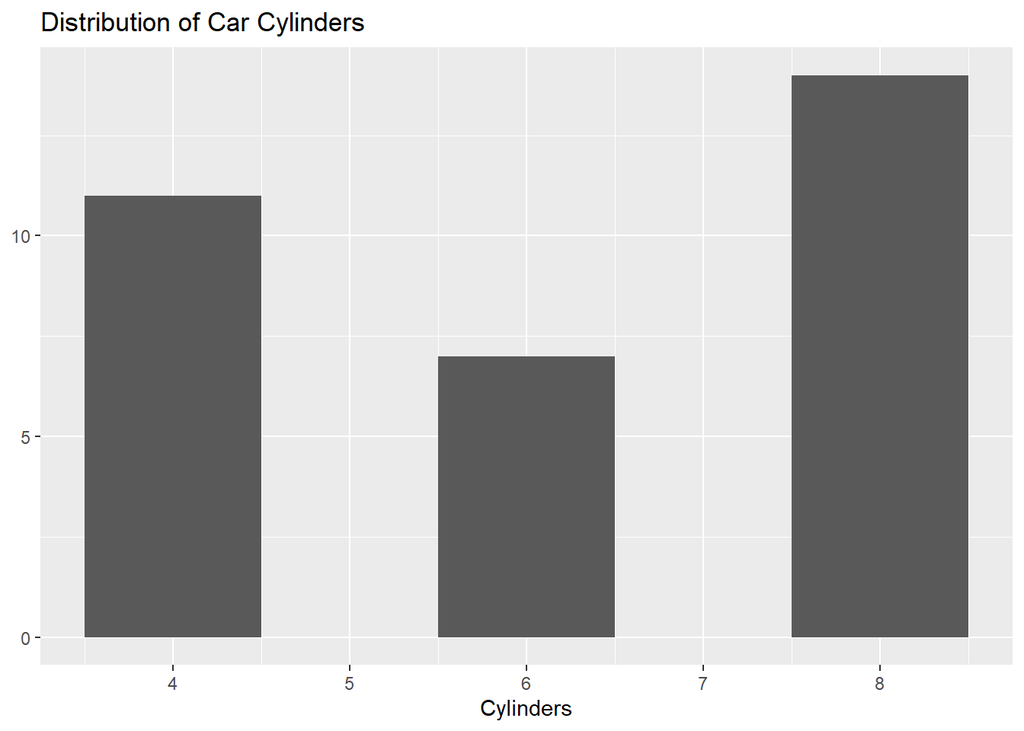

```r
library(ggplot2)
ggplot(carsData, aes(cyl))+
  geom_histogram(bins = 5) +
  labs(title = "Distribution of Car Cylinders", x = "Cylinders", y = NULL)
```

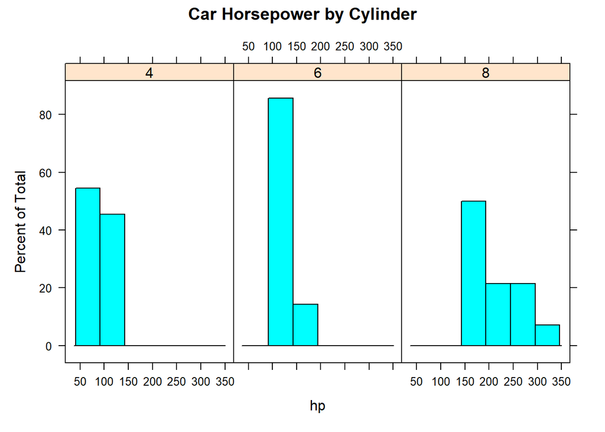

```r
library(lattice)

carsDataNew <- carsData
carsDataNew$cyl <- as.character(carsDataNew$cyl)

histogram(~hp|cyl, data = carsDataNew, layout = c(3,1), main = "Car Horsepower by Cylinder")
```